# Homework_3_BurakhanSel

Burakhan Sel

13 Kasım 2018

## Task 1

Let’s start with data preparation for further steps.

```r
require("data.table")
#Read Data
uWaveGestureLibrary_X_TEST<-as.data.table(read.csv("uWaveGestureLibrary_X_TEST.csv",header = FALSE,sep = ""))
uWaveGestureLibrary_X_TRAIN<-data.table(read.csv("uWaveGestureLibrary_X_TRAIN.csv",header = FALSE,sep = ""))
uWaveGestureLibrary_Y_TEST<-data.table(read.csv("uWaveGestureLibrary_Y_TEST.csv",header = FALSE,sep = ""))
uWaveGestureLibrary_Y_TRAIN<-data.table(read.csv("uWaveGestureLibrary_Y_TRAIN.csv",header = FALSE,sep = ""))
uWaveGestureLibrary_Z_TEST<-data.table(read.csv("uWaveGestureLibrary_Z_TEST.csv",header = FALSE,sep = ""))
uWaveGestureLibrary_Z_TRAIN<-data.table(read.csv("uWaveGestureLibrary_Z_TRAIN.csv",header = FALSE,sep = ""))

#Give names to columns
names(uWaveGestureLibrary_X_TEST)[] <- paste0('x', 1:ncol(uWaveGestureLibrary_X_TEST)-1)
names(uWaveGestureLibrary_X_TEST)[1]<-"class_x_test"
names(uWaveGestureLibrary_X_TRAIN)[] <- paste0('x', 1:ncol(uWaveGestureLibrary_X_TRAIN)-1)
names(uWaveGestureLibrary_X_TRAIN)[1]<-"class_x_train"
names(uWaveGestureLibrary_Y_TEST)[] <- paste0('y', 1:ncol(uWaveGestureLibrary_Y_TEST)-1)
names(uWaveGestureLibrary_Y_TEST)[1]<-"class_y_test"
names(uWaveGestureLibrary_Y_TRAIN)[] <- paste0('y', 1:ncol(uWaveGestureLibrary_Y_TRAIN)-1)
names(uWaveGestureLibrary_Y_TRAIN)[1]<-"class_y_train"
names(uWaveGestureLibrary_Z_TEST)[] <- paste0('z', 1:ncol(uWaveGestureLibrary_Y_TEST)-1)
names(uWaveGestureLibrary_Z_TEST)[1]<-"class_z_test"
names(uWaveGestureLibrary_Z_TRAIN)[] <- paste0('z', 1:ncol(uWaveGestureLibrary_Y_TRAIN)-1)
names(uWaveGestureLibrary_Z_TRAIN)[1]<-"class_z_train"
```

### part a

In order to visualize some instances, I convert the accerelation data to velocity data and location data finally. Let’s see how the instances look like in 3d and try to match the shape with the gesture class.

```r
#converting acceleration information to velocity information
velocity_X_training<-data.table(uWaveGestureLibrary_X_TRAIN[1:10,])
velocity_Y_training<-data.table(uWaveGestureLibrary_Y_TRAIN[1:10,])
velocity_Z_training<-data.table(uWaveGestureLibrary_Z_TRAIN[1:10,])
for(i in 2:ncol(uWaveGestureLibrary_X_TRAIN)){
  for(k in 1:10){
  velocity_X_training[k,i]<-sum(uWaveGestureLibrary_X_TRAIN[k,2:i])
  velocity_Y_training[k,i]<-sum(uWaveGestureLibrary_Y_TRAIN[k,2:i])
  velocity_Z_training[k,i]<-sum(uWaveGestureLibrary_Z_TRAIN[k,2:i])
}}


#converting  velocity information to location information
location_X_training<-data.table(uWaveGestureLibrary_X_TRAIN[1:10,])
location_Y_training<-data.table(uWaveGestureLibrary_Y_TRAIN[1:10,])
location_Z_training<-data.table(uWaveGestureLibrary_Z_TRAIN[1:10,])
for(i in 2:ncol(velocity_X_training)){
  for(k in 1:10){
    location_X_training[k,i]<-sum(velocity_X_training[k,2:i])
    location_Y_training[k,i]<-sum(velocity_Y_training[k,2:i])
    location_Z_training[k,i]<-sum(velocity_Z_training[k,2:i])
  }}
```

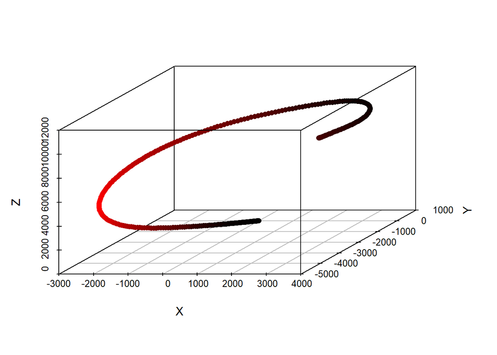

```r
#plotting the locations
library("scatterplot3d")
scatterplot3d(x=location_X_training[6,],y=location_Y_training[6,],z=location_Z_training[6,],type="p", highlight.3d=T, pch=16,xlab = "X",ylab = "Y",zlab = "Z") #class=8
```

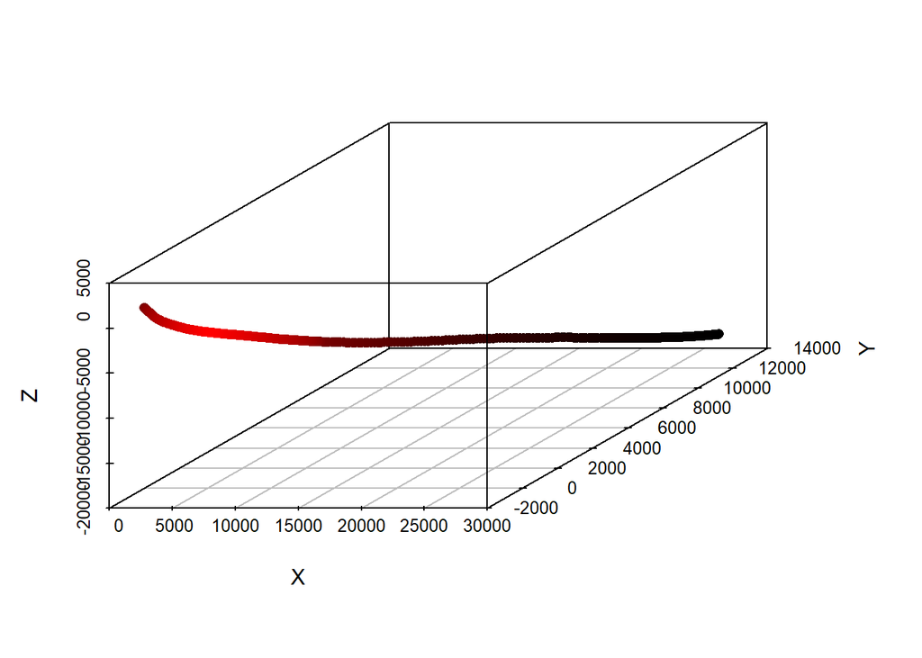

```r
#plotting the locations
scatterplot3d(x=location_X_training[5,],y=location_Y_training[5,],z=location_Z_training[5,],type="p", highlight.3d=T, pch=16,xlab = "X",ylab = "Y",zlab = "Z") #class=4
```

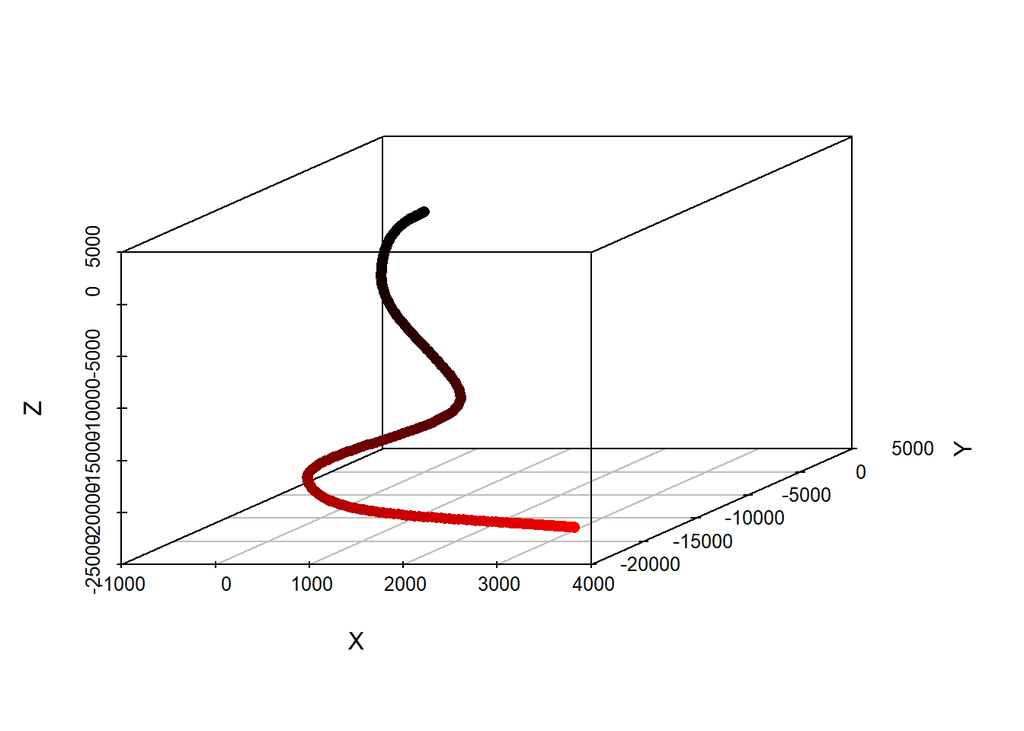

```r
#plotting the locations
scatterplot3d(x=location_X_training[1,],y=location_Y_training[1,],z=location_Z_training[1,],type="p", highlight.3d=T, pch=16,xlab = "X",ylab = "Y",zlab = "Z") #class=6
```

Although 3D visualizations look different than the gestures shown in the vocabulary,the shapes are related to the symbols in the homework description.

### part b

```r
#bind data and seperate class column for train data
train_data<-data.table(cbind(uWaveGestureLibrary_X_TRAIN,uWaveGestureLibrary_Y_TRAIN,uWaveGestureLibrary_Z_TRAIN))
train_class<-train_data[,1]

#remove class columns from train data
class_columns<-c("class_x_test","class_y_train","class_z_train")
train_data <- train_data[,(class_columns):=NULL]
#bind data and seperate class column for test data
test_data<-data.table(cbind(uWaveGestureLibrary_X_TEST,uWaveGestureLibrary_Y_TEST,uWaveGestureLibrary_Z_TEST))
test_class<-test_data[,1]

#remove class columns from test data
class_columns<-c("class_x_test","class_y_test","class_z_test")
test_data <- test_data[,(class_columns):=NULL]
```

From this point, I started to implement cross validation to find optimal k value which minimizes the error. The error is assumed to be 1-(number of accurate predictions)/(number of instances).

As a return, I get an 2 by 10 classification error matrix. Rows are corresponding to the Winkowski distance parameters which are 1 and 2. Columns are corresponding to the k values which are the parameters of knn. Classification errors in each entry is calculated by averaging the classification errors that we get from 10 folds.

```r
require(kknn)
#Randomly shuffle the data
set.seed(3)
shuffled_traindata<-train_data[sample(nrow(train_data)),]
#Create 10 equally size folds
folds <- cut(seq(1,nrow(shuffled_traindata)),breaks=10,labels=FALSE)
fold_classification_error <-array(dim = c(2,10,10))
classification_error <-array(dim=c(2,10))
require("MLmetrics")
#r is the Winkowski's parameter
for (r in 1:2) {
  #k is the nearest neighbour parameter
  for (l in 1:10) {
    #i is the fold index
    for(i in 1:10){
    #Segement your data by fold using the which() function
    validation_Indexes <- which(folds==i,arr.ind=TRUE)
    validationData <- shuffled_traindata[validation_Indexes,]
    trainData_for_knn <- shuffled_traindata[-validation_Indexes, ]
    #Use the test and train data partitions however you desire...
    a<-kknn(as.factor(class_x_train)~.,trainData_for_knn,validationData[,2:ncol(validationData)],distance=r,scale=TRUE,k=l)
    fold_classification_error[r,l,i] <- 1- sum(validationData$class_x_train == a$fitted.values)/length(a$fitted.values)
    }
    classification_error[r,l]<-mean(fold_classification_error[r,l,])
  }
}
```

In the classification error matrix, the column number of minimum of the row 1 will show us the optimal k value for Winkowski 1 distance. The same rule is also valid for the Winkoski distance 2. Let’s check the optimum k values.

```r
print("Optimal k for Winkowski 1 is")
```

```
## [1] "Optimal k for Winkowski 1 is"
```

```r
which.min(classification_error[1,])
```

```
## [1] 6
```

```r
print("Optimal k for Winkowski 2 is")
```

```
## [1] "Optimal k for Winkowski 2 is"
```

```r
which.min(classification_error[2,])
```

```
## [1] 8
```

### part c

For Winkowski distance 1

```r
start_time<-Sys.time()
KNN_dist1_k6<-kknn(as.factor(class_x_train)~.,train_data,test_data,distance=1,scale=TRUE,k=6)
end_time<-Sys.time()
table(test_class$class_x_test,KNN_dist1_k6$fitted.values,dnn=c("True","Predicted"))
```

```
##     Predicted
## True   1   2   3   4   5   6   7   8
##    1 432   0   0   2   0   3   0   0
##    2   1 451   0   0   0   0   0   0
##    3   2   0 418   0  14  15   5   0
##    4   3   0   0 387  47   7   0   6
##    5   3   0   7   1 421   1   0   0
##    6   4   0   4  13  24 404   0   0
##    7   0   0   3   0   0   0 444   0
##    8   0   0   0   2   1   0   0 457
```

```r
runtime1<-end_time-start_time
```

```r
print("runtime is")
```

```
## [1] "runtime is"
```

```r
runtime1
```

```
## Time difference of 1.230038 mins
```

```r
print("accuracy is")
```

```
## [1] "accuracy is"
```

```r
sum(test_class$class_x_test == KNN_dist1_k6$fitted.values)/length(KNN_dist1_k6$fitted.values)
```

```
## [1] 0.9530988
```

For Winkowski distance 2

```r
start_time<-Sys.time()
KNN_dist2_k8<-kknn(as.factor(class_x_train)~.,train_data,test_data,distance=2,scale=TRUE,k=8)
end_time<-Sys.time()
table(test_class$class_x_test,KNN_dist2_k8$fitted.values,dnn=c("True","Predicted"))
```

```
##     Predicted
## True   1   2   3   4   5   6   7   8
##    1 430   0   0   2   0   4   1   0
##    2   1 449   0   0   0   0   2   0
##    3   2   0 416   0  16  15   5   0
##    4   6   0   0 370  59   7   0   8
##    5   3   0   8   0 420   2   0   0
##    6   4   0   4  14  29 398   0   0
##    7   0   0   3   0   0   0 444   0
##    8   0   0   0   2   1   0   0 457
```

```r
runtime2<-end_time-start_time
```

```r
print("runtime is")
```

```
## [1] "runtime is"
```

```r
runtime2
```

```
## Time difference of 8.952292 secs
```

```r
print("accuracy is")
```

```
## [1] "accuracy is"
```

```r
sum(test_class$class_x_test == KNN_dist2_k8$fitted.values)/length(KNN_dist2_k8$fitted.values)
```

```
## [1] 0.9447236
```

## Task 2

I started with doing some arrangements on the data in order to train logistic regression on training data using fused lasso penalties.

```r
require(data.table)
fname='ecgTRAIN' # data path
traindata_ecg <- as.data.table(read.table(fname))  # read train data
traindata_ecg[,V1:=ifelse(V1==-1,0,V1)] #change -1 values to 0. Class values take 0 or 1
trainclass_ecg=traindata_ecg[,1] #first column is the class variable
traindata_ecg=traindata_ecg[,2:ncol(traindata_ecg)] #drop first column

fname='ecgTEST' # data path
testdata_ecg<- as.data.table(read.table(fname))  # read test data
testdata_ecg[,V1:=ifelse(V1==-1,0,V1)]#change -1 values to 0. Class values take 0 or 1
testclass_ecg=testdata_ecg[,1] # #first column is the class variable
testdata_ecg=testdata_ecg[,2:ncol(testdata_ecg)]#drop first column
```

### part a

In order to train fused lasso on our training data, we need to decide lambda1 (from optL1) value. This value corresponds to the lambda value of fused lasso part in the penalty function. One of the ways of determining optimum lambda is cross validation and optL1 implement it for us.

Since there is a possibility of getting local optimum from optL1, I also used profL1 function to check the value that I get from optL1.

The note from the document of optL1 function:

“The optL1 and optL2 functions use Brent’s algorithm for minimization without derivatives (see also optimize). There is a risk that these functions converge to a local instead of to a global optimum. This is especially the case for optL1, as the cross-validated likelihood as a function of lambda1 quite often has local optima. It is recommended to use optL1 in combination with profL1 to check whether optL1 has converged to the right optimum.”

Other parameters for optL1 function are minlambda and maxlambda. I set them equal to 1 and 30. Choosing bigger maxlambda or smaller minlambda doesn’t change the result because lambda values converces around 2 which is between 1 and 30.

```r
require(penalized)
set.seed(1)
cvFused<-optL1(as.factor(trainclass_ecg$V1), penalized=traindata_ecg,minlambda1=1,maxlambda1 =30,lambda2 = 0,
            model = "logistic",standardize = TRUE, fusedl = TRUE,fold=10,epsilon =1e-10,data =traindata_ecg)
```

```
## lambda= 12.07701     12345678910cvl= -55.757
## lambda= 18.92299     12345678910cvl= -63.50887
## lambda= 7.845971     12345678910cvl= -48.64904
## lambda= 5.231043     12345678910cvl= -42.39404
## lambda= 3.614928     12345678910cvl= -38.78539
## lambda= 2.616115     12345678910cvl= -37.04559
## lambda= 1.998814     12345678910cvl= -36.75716
## lambda= 2.011248     12345678910cvl= -36.75705
## lambda= 2.010853     12345678910cvl= -36.75705
## lambda= 2.242286     12345678910cvl= -36.81345
## lambda= 2.099497     12345678910cvl= -36.76698
## lambda= 2.044956     12345678910cvl= -36.76052
## lambda= 2.024123     12345678910cvl= -36.757
## lambda= 2.019429     12345678910cvl= -36.75698
## lambda= 2.019433     12345678910cvl= -36.75698
## lambda= 2.016304     12345678910cvl= -36.75699
## lambda= 2.017886     12345678910cvl= -36.75698
## lambda= 2.018662     12345678910cvl= -36.75698
## lambda= 2.019048     12345678910cvl= -36.75698
```

```r
cvFused$lambda
```

```
## [1] 2.019429
```

```r
set.seed(2)
check<-profL1(as.factor(trainclass_ecg$V1), penalized=traindata_ecg,minlambda1=1,maxlambda1 =10,lambda2 = 0,
      model = "logistic",standardize = TRUE, fusedl = TRUE,fold=10,epsilon =1e-10,data =traindata_ecg)
```

```
## lambda= 10   12345678910cvl= -50.02424
## lambda= 9.909091     12345678910cvl= -49.89192
## lambda= 9.818182     12345678910cvl= -49.75768
## lambda= 9.727273     12345678910cvl= -49.62353
## lambda= 9.636364     12345678910cvl= -49.49082
## lambda= 9.545455     12345678910cvl= -49.35444
## lambda= 9.454545     12345678910cvl= -49.19918
## lambda= 9.363636     12345678910cvl= -49.04305
## lambda= 9.272727     12345678910cvl= -48.88147
## lambda= 9.181818     12345678910cvl= -48.71017
## lambda= 9.090909     12345678910cvl= -48.53962
## lambda= 9    12345678910cvl= -48.36218
## lambda= 8.909091     12345678910cvl= -48.17977
## lambda= 8.818182     12345678910cvl= -47.99576
## lambda= 8.727273     12345678910cvl= -47.81375
## lambda= 8.636364     12345678910cvl= -47.63371
## lambda= 8.545455     12345678910cvl= -47.45565
## lambda= 8.454545     12345678910cvl= -47.27474
## lambda= 8.363636     12345678910cvl= -47.09481
## lambda= 8.272727     12345678910cvl= -46.91685
## lambda= 8.181818     12345678910cvl= -46.73904
## lambda= 8.090909     12345678910cvl= -46.54018
## lambda= 8    12345678910cvl= -46.34332
## lambda= 7.909091     12345678910cvl= -46.14846
## lambda= 7.818182     12345678910cvl= -45.95559
## lambda= 7.727273     12345678910cvl= -45.76471
## lambda= 7.636364     12345678910cvl= -45.57586
## lambda= 7.545455     12345678910cvl= -45.38905
## lambda= 7.454545     12345678910cvl= -45.20439
## lambda= 7.363636     12345678910cvl= -45.02226
## lambda= 7.272727     12345678910cvl= -44.84216
## lambda= 7.181818     12345678910cvl= -44.66168
## lambda= 7.090909     12345678910cvl= -44.48309
## lambda= 7    12345678910cvl= -44.30658
## lambda= 6.909091     12345678910cvl= -44.13265
## lambda= 6.818182     12345678910cvl= -43.96358
## lambda= 6.727273     12345678910cvl= -43.79597
## lambda= 6.636364     12345678910cvl= -43.62887
## lambda= 6.545455     12345678910cvl= -43.4639
## lambda= 6.454545     12345678910cvl= -43.30107
```

[output cut: 45 more lines]

```
## lambda= 2.272727     12345678910cvl= -37.33061
## lambda= 2.181818     12345678910cvl= -37.364
## lambda= 2.090909     12345678910cvl= -37.41669
## lambda= 2    12345678910cvl= -37.47747
## lambda= 1.909091     12345678910cvl= -37.56967
## lambda= 1.818182     12345678910cvl= -37.68858
## lambda= 1.727273     12345678910cvl= -37.80634
## lambda= 1.636364     12345678910cvl= -37.91397
## lambda= 1.545455     12345678910cvl= -37.97103
## lambda= 1.454545     12345678910cvl= -38.00829
## lambda= 1.363636     12345678910cvl= -38.09182
## lambda= 1.272727     12345678910cvl= -38.111
## lambda= 1.181818     12345678910cvl= -37.96193
## lambda= 1.090909     12345678910cvl= -37.75332
## lambda= 1    12345678910cvl= -37.46636
```

```r
max(check$cvl)
```

```
## [1] -37.32334
```

```r
pred.cvFused<-penalized::predict(cvFused$fullfit,testdata_ecg)
pred.cvFused<-ifelse(pred.cvFused>=0.5,1,0)# if the probability is greater than or equal to 0.5, the prediction is 1. Otw 0
conf_matrix<-table(testclass_ecg$V1,t(pred.cvFused),dnn=c("test","pred"))
conf_matrix
```

```
##     pred
## test  0  1
##    0 25 11
##    1  8 56
```

### part b

```r
cvFused$fullfit
```

```
## Penalized logistic regression object
## 97 regression coefficients of which 11 are non-zero
##
## Loglikelihood =   -26.40119
## L1 penalty =  10.06897   at lambda1 =  2.019429
```

With the minimization of fused lasso penalty, we’ve achieved to decrease the number of coefficients in the logistic regression to 11 coefficients. This means that although we’ve increased the bias of the model little bit, we achieved to decrease the variance considerably. In conclusion, this model help us about probability of overfitting.

Let’s check the accuracy from the confusion matrix

```r
(conf_matrix[1,1]+conf_matrix[2,2])/sum(conf_matrix)
```

```
## [1] 0.81
```

We can also look at the precision

```r
(conf_matrix[2,2])/sum(conf_matrix[,2])
```

```
## [1] 0.8358209
```

### part c

Let’s get the nx(m-1) difference matrices

```r
diff_traindata_ecg<-as.data.table(t(diff(t(traindata_ecg),lag = 1,differences = 1))) #(100 by 96)
diff_testdata_ecg<-as.data.table(t(diff(t(testdata_ecg),lag = 1,differences = 1))) #(100 by 96)
```

And Apply the same procedure to find optimum lambda value. This time, I gave very small minlabda because I got lambda values close to 1 and wanted to eliminate the constraint of being bigger than 1.

```r
set.seed(1)
cvFused_diff<-optL1(as.factor(trainclass_ecg$V1), penalized=diff_traindata_ecg,minlambda1=0.0001,maxlambda1 =30,lambda2 = 0, model = "logistic",standardize = TRUE, fusedl = TRUE,fold=10,epsilon =1e-10,data =diff_traindata_ecg)
```

```
## lambda= 11.45904     12345678910cvl= -61.96979
## lambda= 18.54106     12345678910cvl= -64.55813
## lambda= 7.082116     12345678910cvl= -55.80329
## lambda= 4.377026     12345678910cvl= -52.83915
## lambda= 2.705189     12345678910cvl= -49.01632
## lambda= 1.671937     12345678910cvl= -45.48514
## lambda= 1.033352     12345678910cvl= -42.82369
## lambda= 0.638685     12345678910cvl= -44.02961
## lambda= 1.054558     12345678910cvl= -42.92315
## lambda= 0.918045     12345678910cvl= -42.74621
## lambda= 0.811339     12345678910cvl= -42.89358
## lambda= 0.9393678    12345678910cvl= -42.69785
## lambda= 0.9649592    12345678910cvl= -42.66611
## lambda= 0.991083     12345678910cvl= -42.69409
## lambda= 0.9660395    12345678910cvl= -42.66698
## lambda= 0.9551841    12345678910cvl= -42.67227
## lambda= 0.9624549    12345678910cvl= -42.66497
## lambda= 0.9613532    12345678910cvl= -42.66546
## lambda= 0.9627912    12345678910cvl= -42.66483
## lambda= 0.9636193    12345678910cvl= -42.66506
## lambda= 0.9629714    12345678910cvl= -42.66475
## lambda= 0.9632189    12345678910cvl= -42.6648
## lambda= 0.963005     12345678910cvl= -42.66474
```

```r
cvFused_diff$lambda
```

```
## [1] 0.963005
```

The optimum lambda is 0.963005. Since it takes long time to run profL1, I won’t check the local optimality this time.

Let’s calculate the confusion matrix.

```r
pred.cvFused_diff<-penalized::predict(cvFused_diff$fullfit,diff_testdata_ecg)
pred.cvFused_diff<-ifelse(pred.cvFused_diff>=0.5,1,0)
conf_matrix_diff<-table(testclass_ecg$V1,pred.cvFused_diff,dnn=c("test","pred"))
conf_matrix_diff
```

```
##     pred
## test  0  1
##    0 26 10
##    1 10 54
```

### part d

```r
cvFused_diff$fullfit
```

```
## Penalized logistic regression object
## 96 regression coefficients of which 21 are non-zero
##
## Loglikelihood =   -25.71781
## L1 penalty =  12.19405   at lambda1 =  0.963005
```

This time 21 of the coefficients are non-zero in the logistic regression. It is more than the first mordel.

Let’s check the accuracy from the confusion matrix

```r
(conf_matrix_diff[1,1]+conf_matrix_diff[2,2])/sum(conf_matrix_diff)
```

```
## [1] 0.8
```

The accuracy of the model that we obtained by training the difference data is little bit smaller than the previous accuracy. (0.81>0.8)

Let’s look at the precision

```r
(conf_matrix_diff[2,2])/sum(conf_matrix_diff[,2])
```

```
## [1] 0.84375
```

Precision is little bit more than the previous precision (0.8358209<0.84375) However, there is not much difference between two models in terms of accuracy and precision